# What Causes Recipes to get an average rating of below 5

**Name(s)**: Madhav Pudukottai Krishnaraj, Yaqub Mir

**Website Link**: (https://mpkcb21.github.io/recipesdsproject/)

```python
import pandas as pd
import numpy as np
from pathlib import Path

import plotly.express as px
pd.options.plotting.backend = 'plotly'
from sklearn.model_selection import train_test_split
from sklearn.naive_bayes import GaussianNB
from sklearn.metrics import f1_score
from sklearn.model_selection import GridSearchCV
from sklearn.feature_extraction.text import TfidfVectorizer
from sklearn.compose import ColumnTransformer
from sklearn.pipeline import Pipeline
from sklearn.linear_model import LogisticRegression
from sklearn.metrics import confusion_matrix

# from dsc80_utils import * # Feel free to uncomment and use this.
```

## Step 1: Introduction

```python
#reading in data sets
interactions = pd.read_csv('/Users/madhavpudukottaikrishnaraj/Desktop/dsc80-2025-fa/projects/proj04/RAW_interactions.csv')
recipes = pd.read_csv('/Users/madhavpudukottaikrishnaraj/Desktop/dsc80-2025-fa/projects/proj04/RAW_recipes.csv')
```

reading in interactions and recipes datasets

```python
#looking at what recipes looks like
recipes['submitted'] = pd.to_datetime(recipes['submitted'])
```

```python
recipes
```

|  | name | id | minutes | contributor_id | submitted | tags | nutrition | n_steps | steps | description | ingredients | n_ingredients |
| --- | --- | --- | --- | --- | --- | --- | --- | --- | --- | --- | --- | --- |
| 0 | 1 brownies in the world best ever | 333281 | 40 | 985201 | 2008-10-27 | ['60-minutes-or-less', 'time-to-make', 'course... | [138.4, 10.0, 50.0, 3.0, 3.0, 19.0, 6.0] | 10 | ['heat the oven to 350f and arrange the rack i... | these are the most; chocolatey, moist, rich, d... | ['bittersweet chocolate', 'unsalted butter', '... | 9 |
| 1 | 1 in canada chocolate chip cookies | 453467 | 45 | 1848091 | 2011-04-11 | ['60-minutes-or-less', 'time-to-make', 'cuisin... | [595.1, 46.0, 211.0, 22.0, 13.0, 51.0, 26.0] | 12 | ['pre-heat oven the 350 degrees f', 'in a mixi... | this is the recipe that we use at my school ca... | ['white sugar', 'brown sugar', 'salt', 'margar... | 11 |
| 2 | 412 broccoli casserole | 306168 | 40 | 50969 | 2008-05-30 | ['60-minutes-or-less', 'time-to-make', 'course... | [194.8, 20.0, 6.0, 32.0, 22.0, 36.0, 3.0] | 6 | ['preheat oven to 350 degrees', 'spray a 2 qua... | since there are already 411 recipes for brocco... | ['frozen broccoli cuts', 'cream of chicken sou... | 9 |
| 3 | millionaire pound cake | 286009 | 120 | 461724 | 2008-02-12 | ['time-to-make', 'course', 'cuisine', 'prepara... | [878.3, 63.0, 326.0, 13.0, 20.0, 123.0, 39.0] | 7 | ['freheat the oven to 300 degrees', 'grease a ... | why a millionaire pound cake? because it's su... | ['butter', 'sugar', 'eggs', 'all-purpose flour... | 7 |
| 4 | 2000 meatloaf | 475785 | 90 | 2202916 | 2012-03-06 | ['time-to-make', 'course', 'main-ingredient', ... | [267.0, 30.0, 12.0, 12.0, 29.0, 48.0, 2.0] | 17 | ['pan fry bacon , and set aside on a paper tow... | ready, set, cook! special edition contest entr... | ['meatloaf mixture', 'unsmoked bacon', 'goat c... | 13 |
| ... | ... | ... | ... | ... | ... | ... | ... | ... | ... | ... | ... | ... |
| 83777 | zydeco soup | 486161 | 60 | 227978 | 2012-08-29 | ['ham', '60-minutes-or-less', 'time-to-make', ... | [415.2, 26.0, 34.0, 26.0, 44.0, 21.0, 15.0] | 7 | ['heat oil in a 4-quart dutch oven', 'add cele... | this is a delicious soup that i originally fou... | ['celery', 'onion', 'green sweet pepper', 'gar... | 22 |
| 83778 | zydeco spice mix | 493372 | 5 | 1500678 | 2013-01-09 | ['15-minutes-or-less', 'time-to-make', 'course... | [14.8, 0.0, 2.0, 58.0, 1.0, 0.0, 1.0] | 1 | ['mix all ingredients together thoroughly'] | this spice mix will make your taste buds dance! | ['paprika', 'salt', 'garlic powder', 'onion po... | 13 |
| 83779 | zydeco ya ya deviled eggs | 308080 | 40 | 37779 | 2008-06-07 | ['60-minutes-or-less', 'time-to-make', 'course... | [59.2, 6.0, 2.0, 3.0, 6.0, 5.0, 0.0] | 7 | ['in a bowl , combine the mashed yolks and may... | deviled eggs, cajun-style | ['hard-cooked eggs', 'mayonnaise', 'dijon must... | 8 |
| 83780 | cookies by design cookies on a stick | 298512 | 29 | 506822 | 2008-04-15 | ['30-minutes-or-less', 'time-to-make', 'course... | [188.0, 11.0, 57.0, 11.0, 7.0, 21.0, 9.0] | 9 | ['place melted butter in a large mixing bowl a... | i've heard of the 'cookies by design' company,... | ['butter', 'eagle brand condensed milk', 'ligh... | 10 |
| 83781 | cookies by design sugar shortbread cookies | 298509 | 20 | 506822 | 2008-04-15 | ['30-minutes-or-less', 'time-to-make', 'course... | [174.9, 14.0, 33.0, 4.0, 4.0, 11.0, 6.0] | 5 | ['whip sugar and shortening in a large bowl , ... | i've heard of the 'cookies by design' company,... | ['granulated sugar', 'shortening', 'eggs', 'fl... | 7 |

83782 rows × 12 columns

```python
#looking at what interactions looks like
interactions['date'] = pd.to_datetime(interactions['date'])
interactions
```

|  | user_id | recipe_id | date | rating | review |
| --- | --- | --- | --- | --- | --- |
| 0 | 1293707 | 40893 | 2011-12-21 | 5 | So simple, so delicious! Great for chilly fall... |
| 1 | 126440 | 85009 | 2010-02-27 | 5 | I made the Mexican topping and took it to bunk... |
| 2 | 57222 | 85009 | 2011-10-01 | 5 | Made the cheddar bacon topping, adding a sprin... |
| 3 | 124416 | 120345 | 2011-08-06 | 0 | Just an observation, so I will not rate. I fo... |
| 4 | 2000192946 | 120345 | 2015-05-10 | 2 | This recipe was OVERLY too sweet. I would sta... |
| ... | ... | ... | ... | ... | ... |
| 731922 | 2002357020 | 82303 | 2018-12-05 | 5 | Delicious quick thick chocolate sauce with ing... |
| 731923 | 583662 | 386618 | 2009-09-29 | 5 | These were so delicious! My husband and I tru... |
| 731924 | 157126 | 78003 | 2008-06-23 | 5 | WOW! Sometimes I don't take the time to rate ... |
| 731925 | 53932 | 78003 | 2009-01-11 | 4 | Very good! I used regular port as well. The ... |
| 731926 | 2001868099 | 78003 | 2017-12-18 | 5 | I am so glad I googled and found this here. Th... |

731927 rows × 5 columns

## Step 2: Data Cleaning and Exploratory Data Analysis

## Data Cleaning

```python
pd.set_option('display.max_columns', None)
#combining the two dataframes
import json

combined = recipes.merge(interactions,how='left',left_on='id',right_on='recipe_id')
combined['rating'] = combined['rating'].replace(0,np.nan)
#need to do this to access the nutritional information as the
#list is loaded in as a string
combined['user_id'] = combined['user_id'].astype('Int64')
combined['recipe_id'] = combined['recipe_id'].astype('Int64')
```

```python
combined["nutrition"] = combined["nutrition"].apply(lambda x: json.loads(x) if isinstance(x, str) else x)

#unpack nutrition
combined['calories'] = combined['nutrition'].apply(lambda x: float(x[0]) if isinstance(x, list) else np.nan)
combined['total_fat(PDV)'] = combined['nutrition'].apply(lambda x: float(x[1]) if isinstance(x, list) else np.nan)
combined['sugar(PDV)'] = combined['nutrition'].apply(lambda x: float(x[2]) if isinstance(x, list) else np.nan)
combined['sodium(PDV)'] = combined['nutrition'].apply(lambda x: float(x[3]) if isinstance(x, list) else np.nan)
combined['protein(PDV)'] = combined['nutrition'].apply(lambda x: float(x[4]) if isinstance(x, list) else np.nan)
combined['saturated_fat(PDV)'] = combined['nutrition'].apply(lambda x: float(x[5]) if isinstance(x, list) else np.nan)
combined['carbohydrates(PDV)'] = combined['nutrition'].apply(lambda x: float(x[6]) if isinstance(x, list) else np.nan)
#convert date to the year the review was submitted
combined['year'] = pd.to_datetime(combined['date']).dt.year


with_missing = combined.copy()
with_missing['rating'] = with_missing['rating'].replace(np.nan, 0)
```

```python
# Added avg rating column
avg_rating = (combined.groupby("recipe_id")["rating"].mean().reset_index().rename(columns={"rating": "avg_rating"}))
combined = combined.merge(avg_rating,left_on="id",right_on="recipe_id",how="left")
```

```python
combined = combined.rename(columns={'recipe_id_x': 'recipe_id'})
combined['recipe_id'].isna().sum()
```

```
np.int64(1)
```

-left merged the recipes and interactions datasets together (works for my project because it basically just matches every user that has a rating for every recipe in recipes so it just drops users that doesnt have an interactiong in recipes)

-replaced 0s in the rating column with nans because they are missing values

-avg_rating added to combined df

```python
numeric_df = combined.select_dtypes(include=["int64", "float64"])
corr = numeric_df.corr()
corr
```

|  | id | minutes | contributor_id | n_steps | n_ingredients | user_id | recipe_id | rating | calories | total_fat(PDV) | sugar(PDV) | sodium(PDV) | protein(PDV) | saturated_fat(PDV) | carbohydrates(PDV) | year |
| --- | --- | --- | --- | --- | --- | --- | --- | --- | --- | --- | --- | --- | --- | --- | --- | --- |
| id | 1.000000 | 0.001719 | 0.174941 | 0.083079 | 0.055759 | 0.150081 | 1.000000 | 0.024654 | 0.021727 | 0.025629 | 0.005289 | 0.010359 | 0.009852 | 0.016987 | 0.013265 | 0.463531 |
| minutes | 0.001719 | 1.000000 | 0.000253 | 0.011695 | -0.006963 | 0.001843 | 0.001718 | 0.001440 | 0.005562 | 0.001066 | 0.004530 | 0.004382 | 0.003112 | 0.002345 | 0.006786 | 0.001020 |
| contributor_id | 0.174941 | 0.000253 | 1.000000 | 0.050131 | 0.008876 | 0.172145 | 0.174941 | 0.002215 | 0.019978 | 0.020717 | 0.014018 | 0.031788 | 0.005361 | 0.013757 | 0.015679 | 0.131004 |
| n_steps | 0.083079 | 0.011695 | 0.050131 | 1.000000 | 0.408890 | 0.081390 | 0.083077 | -0.001101 | 0.152484 | 0.132764 | 0.045285 | 0.022865 | 0.152408 | 0.143201 | 0.104727 | 0.100449 |
| n_ingredients | 0.055759 | -0.006963 | 0.008876 | 0.408890 | 1.000000 | 0.013214 | 0.055756 | -0.005005 | 0.132949 | 0.116539 | 0.004624 | 0.041202 | 0.188083 | 0.092708 | 0.075900 | 0.044061 |
| user_id | 0.150081 | 0.001843 | 0.172145 | 0.081390 | 0.013214 | 1.000000 | 0.150081 | -0.116926 | 0.047905 | 0.038758 | 0.035878 | 0.023525 | 0.034467 | 0.042853 | 0.040174 | 0.665861 |
| recipe_id | 1.000000 | 0.001718 | 0.174941 | 0.083077 | 0.055756 | 0.150081 | 1.000000 | 0.024654 | 0.021730 | 0.025633 | 0.005288 | 0.010360 | 0.009857 | 0.016991 | 0.013265 | 0.463531 |
| rating | 0.024654 | 0.001440 | 0.002215 | -0.001101 | -0.005005 | -0.116926 | 0.024654 | 1.000000 | -0.009316 | -0.001542 | -0.006584 | -0.004567 | -0.011787 | -0.003704 | -0.012925 | -0.054522 |
| calories | 0.021727 | 0.005562 | 0.019978 | 0.152484 | 0.132949 | 0.047905 | 0.021730 | -0.009316 | 1.000000 | 0.869702 | 0.681099 | 0.216373 | 0.593704 | 0.805539 | 0.812777 | 0.046457 |
| total_fat(PDV) | 0.025629 | 0.001066 | 0.020717 | 0.132764 | 0.116539 | 0.038758 | 0.025633 | -0.001542 | 0.869702 | 1.000000 | 0.403276 | 0.123399 | 0.510125 | 0.862350 | 0.459807 | 0.043893 |
| sugar(PDV) | 0.005289 | 0.004530 | 0.014018 | 0.045285 | 0.004624 | 0.035878 | 0.005288 | -0.006584 | 0.681099 | 0.403276 | 1.000000 | 0.208057 | 0.126688 | 0.473522 | 0.854467 | 0.024075 |
| sodium(PDV) | 0.010359 | 0.004382 | 0.031788 | 0.022865 | 0.041202 | 0.023525 | 0.010360 | -0.004567 | 0.216373 | 0.123399 | 0.208057 | 1.000000 | 0.178635 | 0.108751 | 0.230417 | 0.026456 |
| protein(PDV) | 0.009852 | 0.003112 | 0.005361 | 0.152408 | 0.188083 | 0.034467 | 0.009857 | -0.011787 | 0.593704 | 0.510125 | 0.126688 | 0.178635 | 1.000000 | 0.461502 | 0.271469 | 0.036604 |
| saturated_fat(PDV) | 0.016987 | 0.002345 | 0.013757 | 0.143201 | 0.092708 | 0.042853 | 0.016991 | -0.003704 | 0.805539 | 0.862350 | 0.473522 | 0.108751 | 0.461502 | 1.000000 | 0.496340 | 0.042453 |
| carbohydrates(PDV) | 0.013265 | 0.006786 | 0.015679 | 0.104727 | 0.075900 | 0.040174 | 0.013265 | -0.012925 | 0.812777 | 0.459807 | 0.854467 | 0.230417 | 0.271469 | 0.496340 | 1.000000 | 0.032256 |
| year | 0.463531 | 0.001020 | 0.131004 | 0.100449 | 0.044061 | 0.665861 | 0.463531 | -0.054522 | 0.046457 | 0.043893 | 0.024075 | 0.026456 | 0.036604 | 0.042453 | 0.032256 | 1.000000 |

looking at correlation of all numeric columns to rating, largest coefficient is user_id although weak, but it is negative. Even though contributor id is a categorical value, depending on if newer users have a larger contributer id in terms of numerical value, it could mean that newer users rate lower on average

```python
#feature engineering a count on how many reviews a user has made
user_counts = combined.groupby("user_id").size().rename("user_review_count")
# Merge into main DataFrame
combined = combined.merge(user_counts, on="user_id", how="left")

user_counts_wm = with_missing.groupby("user_id").size().rename("user_review_count")
with_missing = with_missing.merge(user_counts_wm, on="user_id", how="left")
```

Adding user review count as a new feature to see if user experience has to do with rating later on

```python
combined[['id', 'year', 'rating', 'avg_rating', 'user_id', 'user_review_count']]
```

|  | id | year | rating | avg_rating | user_id | user_review_count |
| --- | --- | --- | --- | --- | --- | --- |
| 0 | 333281 | 2008.0 | 4.0 | 4.0 | 386585 | 959.0 |
| 1 | 453467 | 2012.0 | 5.0 | 5.0 | 424680 | 4934.0 |
| 2 | 306168 | 2008.0 | 5.0 | 5.0 | 29782 | 73.0 |
| 3 | 306168 | 2009.0 | 5.0 | 5.0 | 1196280 | 1.0 |
| 4 | 306168 | 2013.0 | 5.0 | 5.0 | 768828 | 70.0 |
| ... | ... | ... | ... | ... | ... | ... |
| 234424 | 308080 | 2009.0 | 5.0 | 5.0 | 844554 | 492.0 |
| 234425 | 298512 | 2008.0 | 1.0 | 1.0 | 804234 | 1.0 |
| 234426 | 298509 | 2008.0 | 1.0 | 3.0 | 866651 | 1.0 |
| 234427 | 298509 | 2010.0 | 5.0 | 3.0 | 1546277 | 1.0 |
| 234428 | 298509 | 2014.0 | NaN | 3.0 | 1803287907 | 1.0 |

234429 rows × 6 columns

columns we use throughout our project(add more later on) based off these as well

## Univariate Analysis

```python
#distribution of reviews
fig = px.histogram(
    combined,
    x="rating",
    title="Distribution of Recipe Ratings on Food.com"
)
fig.update_layout(template="plotly_white")
fig.show()
combined['rating'].value_counts(normalize=True)
```

```
rating
5.0    0.773388
4.0    0.170046
3.0    0.032690
1.0    0.013082
2.0    0.010793
Name: proportion, dtype: float64
```

```python
#distribution of user review count
fig = px.histogram(
    combined,
    x="user_review_count",
    nbins=50,
    title="Distribution of Reviewer Experience",
    labels={"user_review_count": "Number of Past Reviews"},
)

fig.update_layout(template="plotly_white")
fig.show()
```

## Bivariate Test

```python
#making a categorical activity column
combined["reviewer_group"] = pd.qcut(combined["user_review_count"],q=3,labels=["Low Activity", "Medium Activity", "High Activity"])
combined["not_five"] = (combined["rating"] < 5).astype(int)

# Group + get mean dissatisfaction rates
reviewer_diss = (combined.groupby("reviewer_group")["not_five"].mean().reset_index())

fig = px.bar(
    reviewer_diss,
    x="reviewer_group",
    y="not_five",
    title="Dissatisfaction Rate by Reviewer Experience(Defined by ratings less than 5)",
    labels={
        "reviewer_group": "Reviewer Activity Level",
        "not_five": "Fraction of Non-5-Star Ratings"
    },
    text=reviewer_diss["not_five"].map(lambda x: f"{x:.2%}")
)

fig.update_layout(template="plotly_white", yaxis_tickformat=".0%")
fig.show()
```

basically split the user review counts into 3 groups based off percentile based off percentile equally to see the dissatisfaction rate of each group (basically rate of non 5 star reviews within the group)

```python
#making a categorical activity column
with_missing["reviewer_group"] = pd.qcut(with_missing["user_review_count"],q=3,labels=["Low Activity", "Medium Activity", "High Activity"])
with_missing["not_five"] = (with_missing["rating"] < 5).astype(int)

# Group + get mean dissatisfaction rates
reviewer_diss = (
    with_missing.groupby("reviewer_group")["not_five"]
            .mean()
            .reset_index()
)

fig = px.bar(
    reviewer_diss,
    x="reviewer_group",
    y="not_five",
    title="Dissatisfaction Rate by Reviewer Experience (With Values that have ratings of 0)",
    labels={
        "reviewer_group": "Reviewer Activity Level",
        "not_five": "Fraction of Non-5-Star Ratings"
    },
    text=reviewer_diss["not_five"].map(lambda x: f"{x:.2%}")
)

fig.update_layout(template="plotly_white", yaxis_tickformat=".0%")
fig.show()
```

```python
#average rating by reviewer group
group_avg = combined.groupby("reviewer_group")["rating"].mean().reset_index()

fig = px.bar(
    group_avg,
    x="reviewer_group",
    y="rating",
    title="Average Rating per Reviewer Activity Group",
    labels={
        "reviewer_group": "Reviewer Activity Level",
        "rating": "Average Rating"
    },
    text=group_avg["rating"].round(2)  # display values rounded to 2 decimals
)

fig.update_traces(
    textposition="outside",  # place values above the bars
    cliponaxis=False         # ensures text isn't clipped by graph bounds
)

fig.update_layout(
    template="plotly_white",
    yaxis=dict(range=[0, group_avg["rating"].max() + 0.2])  # add extra headroom
)

fig.show()
```

```python
#trend line of non-5-Star Ratings over Time
trend = (
    combined.groupby("year")["not_five"]
    .mean()
    .reset_index()
)

import plotly.express as px

fig = px.line(
    trend,
    x="year",
    y="not_five",
    markers=True,
    title="Trend of % Non-5-Star Ratings Over Time",
    labels={
        "year": "Year",
        "not_five_star": "Fraction of Non-5-Star Ratings"
    }
)

fig.update_layout(template="plotly_white")
fig.show()
```

```python
#heatmap of avg rating between activity year and rating
heatmap_df = (
    combined.groupby(["reviewer_group", "year"])["rating"]
              .mean()
              .reset_index()
)

fig = px.imshow(
    heatmap_df.pivot(index="reviewer_group", columns="year", values="rating"),
    aspect="auto",
    color_continuous_scale="Viridis",
    title="Avg Rating by Reviewer Group Over Time",
    labels={"color": "Avg Rating"}
)

fig.update_layout(template="plotly_white")
fig.show()
```

## Interesting Aggregates

```python
#used everything outside of recipe_id to explore but decided that nothing was too significant
recipe_stats = (combined.groupby(["recipe_id"])["rating"].agg(["mean", "std", "count"]).reset_index())
recipe_stats["std"] = recipe_stats["std"].fillna(0)
recipe_stats["is_perfect"] = (recipe_stats["mean"] == 5).astype(int)
recipe_stats["dissatisfaction_rate"] = 1 - (recipe_stats["mean"] / 5)
```

```python
def classify(row, mean_threshold=4.0):

    #Perfect = nothing to explain
    if row["mean"] == 5:
        return "Perfect"

    #Clear recipe flaw: universally mediocre/bad
    if row["mean"] < mean_threshold:
        return "Recipe Flaw Likely"
    if row['std'] < 1:
        return 'User-Preference/Flaw'
    #Any disagreement = preference or execution issues
    return "Disagreement-Driven"

recipe_stats["issue_type"] = recipe_stats.apply(classify, axis=1)
```

**I created groups of possible reasons why a recipe would not get a 5 by either it being perfect, user-preference/flaw, recipe flaw, and disagreement-driven(basically neither the recipe or users flaw). I did so by agrregating the means and standard deviations of each recipe and assigned proper thresholds to divide the recipes. Basically saying that if the recipe had a higher average rating and the standard deviation was low it was probably the users preference or flaw that they mean of the recipe is not a perfect 5. If its a high mean but also a high standard deviation it implies that there is a high variation and that the high average doesn't really mean that its a user flaw as many people are rating below a 5, which leads to a disagreement driven score for the recipe. I also said that if the recipe has a average score of below 4 it just means that the recipe was flawed as that was scores below 4 are quite rare anyways so standard deviation doesnt matter at that point.**

```python
mean_thresholds = np.arange(1,5,0.1)

results = {}

# Build distribution table
for mt in mean_thresholds:
    col_name = f"MT≥{mt}"
    recipe_stats[col_name] = recipe_stats.apply(classify, axis=1,mean_threshold=mt,)
    results[mt] = (recipe_stats[col_name].value_counts(normalize=True).round(3))

# Combine into a dataframe
sensitivity_df = pd.DataFrame(results).fillna(0)
sensitivity_df.index.name = "Issue Type"
sensitivity_df
```

| Issue Type | 1.0 | 1.1 | 1.2 | 1.3 | 1.4 | 1.5 | 1.6 | 1.7 | 1.8 | 1.9 | 2.0 | 2.1 | 2.2 | 2.3 | 2.4 | 2.5 | 2.6 | 2.7 | 2.8 | 2.9 | 3.0 | 3.1 | 3.2 | 3.3 | 3.4 | 3.5 | 3.6 | 3.7 | 3.8 | … |
| --- | --- | --- | --- | --- | --- | --- | --- | --- | --- | --- | --- | --- | --- | --- | --- | --- | --- | --- | --- | --- | --- | --- | --- | --- | --- | --- | --- | --- | --- | --- |
| Disagreement-Driven | 0.051 | 0.051 | 0.051 | 0.051 | 0.051 | 0.051 | 0.051 | 0.050 | 0.050 | 0.050 | 0.050 | 0.050 | 0.050 | 0.050 | 0.050 | 0.049 | 0.049 | 0.048 | 0.048 | 0.048 | 0.043 | 0.043 | 0.042 | 0.042 | 0.041 | 0.037 | 0.037 | 0.034 | 0.033 | … |
| Perfect | 0.570 | 0.570 | 0.570 | 0.570 | 0.570 | 0.570 | 0.570 | 0.570 | 0.570 | 0.570 | 0.570 | 0.570 | 0.570 | 0.570 | 0.570 | 0.570 | 0.570 | 0.570 | 0.570 | 0.570 | 0.570 | 0.570 | 0.570 | 0.570 | 0.570 | 0.570 | 0.570 | 0.570 | 0.570 | … |
| Recipe Flaw Likely | 0.000 | 0.007 | 0.007 | 0.007 | 0.007 | 0.007 | 0.007 | 0.007 | 0.007 | 0.007 | 0.015 | 0.015 | 0.015 | 0.015 | 0.015 | 0.016 | 0.016 | 0.017 | 0.017 | 0.017 | 0.047 | 0.047 | 0.047 | 0.047 | 0.049 | 0.057 | 0.057 | 0.061 | 0.063 | … |
| User-Preference/Flaw | 0.379 | 0.372 | 0.372 | 0.372 | 0.372 | 0.372 | 0.372 | 0.372 | 0.372 | 0.372 | 0.365 | 0.365 | 0.365 | 0.365 | 0.365 | 0.365 | 0.365 | 0.365 | 0.365 | 0.365 | 0.340 | 0.340 | 0.340 | 0.340 | 0.340 | 0.336 | 0.335 | 0.335 | 0.334 | … |

**This just shows the difference in proportions as the threshold for mean changes**

```python
import plotly.express as px
#image to show the distribution of potential reasons why a recipe did not get a perfect 5
fig = px.scatter(
    recipe_stats,
    x="mean",
    y="std",
    color="issue_type",
    title="Recipe Quality vs Rating Disagreement",
    labels={"mean": "Mean Rating", "std": "Rating Standard Deviation"},
    opacity=0.6,
)

fig.update_layout(template="plotly_white")
fig.show()
```

## Step 3: Assessment of Missingness

## NMAR Analysis

We believe that the text column of the reviews dataset is Not missing at random because new reviewers are not as confident in their opinions and are afraid to express their opinions in a forum where there are people that have more experience in fear of being judged, as people can respond to your review. This would cause people with less experience writing reviews on a recipe to refrain from doing so as they do not want to be condemned for their opinion (fear of your opinion being wrong or different from the general population)

## Hypothesis Testing for Missingness

```python
#observed test stat
combined["rating_missing"] = combined["rating"].isna()
obs_diff = combined.groupby("rating_missing")["user_review_count"].mean().diff().iloc[-1]
obs_diff
```

```
np.float64(-410.22373049712206)
```

**Null Hypothesis:** The missingness of the ratings does not depend on the user review count of the user rating the recipe

**Alternate Hypothesis:** The missingness of the ratings does depend on the user review count of the user rating the recipe

**Test statistic:** = The difference of mean in the user review count of the distribution of the population without missing ratings and with missing ratings

**Significance Level:** = 0.05

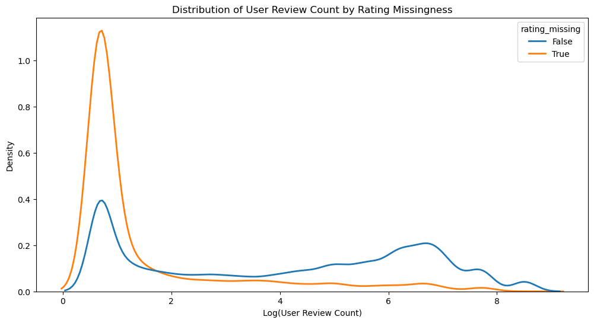

```python
import seaborn as sns
import matplotlib.pyplot as plt
import numpy as np

# Create indicator if not yet made
combined["rating_missing"] = combined["rating"].isna()

#Take log to scale the plot to a more viewable level
combined["log_reviews"] = np.log1p(combined["user_review_count"])
#plot to show the difference in distribution between missing and not missing values
plt.figure(figsize=(12,6))
sns.kdeplot(
    data=combined,
    x="log_reviews",
    hue="rating_missing",
    common_norm=False,
    linewidth=2
)

plt.title("Distribution of User Review Count by Rating Missingness")
plt.xlabel("Log(User Review Count)")
plt.ylabel("Density")
plt.show()
```

```python
np.random.seed(42)
#permutation test
test_stats = []
n_perm = 10000

for _ in range(n_perm):
    shuffled = combined["rating_missing"].sample(frac=1, replace=False).values
    diff = (
        combined.groupby(shuffled)["user_review_count"].mean().diff().iloc[-1])
    test_stats.append(diff)

test_stats = np.array(test_stats)

p_value = np.mean(np.abs(test_stats) >= np.abs(obs_diff))
p_value
```

```
np.float64(0.0)
```

```python
#test statistic distribution plot
fig = px.histogram(
    test_stats,
    nbins=40,
    title="Permutation Test Statistic Distribution",
    labels={"value": "Difference in Mean Review Count"}
)

fig.add_vline(x=obs_diff, line_width=3, line_color="red", name="Observed Stat")

fig.update_layout(template="plotly_white")
fig.show()
```

We can reject the null hypotheses at a 0.05 confidence level because our p-value was 0 and less than 0.05 so we have significant statistical evidence to reject the null

## Part 2

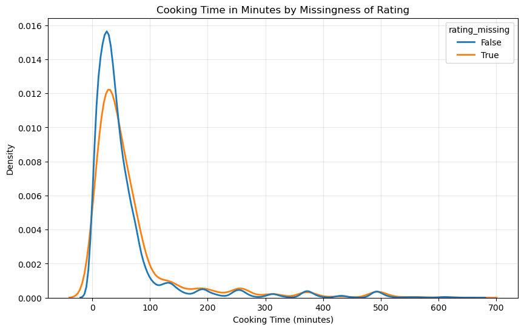

```python
import seaborn as sns
import matplotlib.pyplot as plt

#filter minutes to remove extreme outliers for visibility
trimmed = combined[combined["minutes"] <= combined["minutes"].quantile(0.99)]
#plot to show the difference in distribution between missing and not missing values
plt.figure(figsize=(10, 6))
sns.kdeplot(
    data=trimmed,
    x="minutes",
    hue="rating_missing",
    fill=False,
    common_norm=False,
    linewidth=2,
)

plt.title("Cooking Time in Minutes by Missingness of Rating")
plt.xlabel("Cooking Time (minutes)")
plt.ylabel("Density")
plt.grid(alpha=0.3)
plt.show()
```

**Null Hypothesis:** The missingness of the ratings does not depend on the amount of minutes it takes to complete a recipe

**Alternate Hypothesis:** The missingness of the ratings does depend on the amount of minutes it takes to complete a recipe

**Test statistic:** = The difference of mean in the minutes it takes for a recipe of the distribution of the population without missing ratings and with missing ratings

**Significance level:** = 0.05

```python
import numpy as np
import plotly.express as px

# Observed test statistic
obs_missing = combined[combined["rating_missing"] == True]["minutes"].mean()
obs_not_missing = combined[combined["rating_missing"] == False]["minutes"].mean()
obs_stat = obs_missing - obs_not_missing

# Permutation test
stats = []
for _ in range(10000):
    shuffled = (
        combined["rating_missing"]
        .sample(frac=1, replace=False)
        .reset_index(drop=True)
    )
    stat = combined.groupby(shuffled)["minutes"].mean().diff().iloc[-1]
    stats.append(stat)

p_value = np.mean(stats >= obs_stat)

print("Observed Statistic:", obs_stat)
print("p-value:", p_value)

#test statistic distribution plot
fig = px.histogram(
    stats,
    nbins=50,
    title="Permutation Test: Missingness vs Minutes",
    labels={"value": "Difference in Mean Minutes"}
)

fig.add_vline(
    x=obs_stat,
    line_width=3,
    line_color="red",
    annotation_text="Observed Statistic",
    annotation_position="top right"
)

fig.update_layout(template="plotly_white")
fig.show()
```

```
Observed Statistic: 51.45237039852127
p-value: 0.1171
```

We can't reject the null hypotheses at a 0.05 confidence level because our p-value was 0.1171 and greater than 0.05 so we don't have significant statistical evidence to reject the null

## Step 4: Hypothesis Testing

**Null:** Low activity users rate on the same scale as higher activity users (split is classified from the pdqcut in the exploratory analysis portion)

**Alternative:** Low activity users tend to rate on a lower scale compared to higher activity users

**Test Statistic:** The difference in mean rating between low activity users and higher activity users

**Significance Level:** = 0.05

```python
import numpy as np
import plotly.express as px

# Drop missing to avoid issues just in case
test_df = combined.dropna(subset=["rating", "reviewer_group"]).copy()
#make the two different groups
low = test_df[test_df["reviewer_group"] == "Low Activity"]["rating"]
others = test_df[test_df["reviewer_group"] != "Low Activity"]["rating"]
#obeserved test statistic
obs_stat = low.mean() - others.mean()
print("Observed Statistic (Low - Others):", obs_stat)
#permutation test
stats = []
for _ in range(1000):
    shuffled = (test_df["reviewer_group"].sample(frac=1, replace=False).reset_index(drop=True))

    perm_df = test_df.copy()
    perm_df["shuffled_group"] = shuffled

    low_perm = perm_df[perm_df["shuffled_group"] == "Low Activity"]["rating"]
    others_perm = perm_df[perm_df["shuffled_group"] != "Low Activity"]["rating"]

    stat = low_perm.mean() - others_perm.mean()
    stats.append(stat)

p_value = np.mean(np.array(stats) <= obs_stat)

print(f"P-value: {p_value:.4f}")
#test statistic distribution histogram
fig = px.histogram(
    stats,
    nbins=50,
    title="Permutation Test: Low Activity vs All Others (Ratings)",
    labels={"value": "Difference in Mean Rating"}
)

fig.add_vline(
    x=obs_stat,
    line_width=3,
    line_color="red",
    annotation_text="Observed Statistic",
    annotation_position="top right"
)

fig.update_layout(template="plotly_white")
fig.show()
```

```
Observed Statistic (Low - Others): -0.18244573278442822
P-value: 0.0000
```

**We can reject the null hypothesis because we got a pvalue of 0 which is less than 0.05, so we have statistically significant evidence to reject the null**

## Step 5: Framing a Prediction Problem

We are going to make a model that predicts whether a rating is going to be good (4 or 5) or bad (1, 2, or 3)

## Step 6: Baseline Model

```python
#our binary target
combined["good_rating"] = (combined["rating"] >= 4).astype(int)

#feature engineer a feature that shows us how many reviews that recipe already had before this one

combined["recipe_review_count"] = combined.groupby("recipe_id").cumcount()

#setup data for modeling
features = ["user_review_count", "recipe_review_count"]
X = combined[features]
y = combined["good_rating"]

X_train, X_test, y_train, y_test = train_test_split(
    X, y,
    test_size=0.25,
    random_state=42,
    stratify=y
)

#Naive Bayes Baseline Model

nb = GaussianNB()
nb.fit(X_train, y_train)
y_pred = nb.predict(X_test)

baseline_f1 = f1_score(y_test, y_pred)
```

```python
#confusion matrix
cm = confusion_matrix(y_test, y_pred, labels=[1, 0])

cm_df = pd.DataFrame(
    cm,
    index=["Actual Good (1)", "Actual Bad (0)"],
    columns=["Pred Good (1)", "Pred Bad (0)"]
)

fig = px.imshow(
    cm_df,
    text_auto=True,
    color_continuous_scale="Oranges",
    title="Confusion Matrix — Naive Bayes Baseline Model"
)

fig.update_layout(
    xaxis_title="Predicted Label",
    yaxis_title="True Label",
    template="plotly_white"
)

fig.show()
```

## Step 7: Final Model

```python
#TF-IDF + Logistic Regression model(log regr with tf idf allows us to do a log regr using text feature and extract emotions written in a review)
# Replace missing review text with empty string
combined["review_text"] = combined["review"].fillna("")

# Past user rating average - subtract the current columns rating so the column we are using is not used to predict itself, basically use user_counts in a more meaningful way
combined = combined.sort_values("date")
combined["past_review_count"] = combined.groupby("user_id").cumcount()
combined["past_rating_sum"] = combined.groupby("user_id")["rating"].cumsum() - combined["rating"]
combined["user_avg_rating_past"] = combined["past_rating_sum"] / combined["past_review_count"]
combined["user_avg_rating_past"] = combined["user_avg_rating_past"].fillna(combined["rating"].mean())

# Split data
X = combined[["review_text", "user_avg_rating_past", "recipe_review_count", ]]
y = combined["good_rating"]

X_train, X_test, y_train, y_test = train_test_split(X, y, test_size=0.25, random_state=42, stratify=y)

# Column Transformer
preprocess = ColumnTransformer(transformers=[("tfidf", TfidfVectorizer(max_features=3000, stop_words="english"), "review_text"),("num", "passthrough", ["user_avg_rating_past", "recipe_review_count"])])

# Build a modeling pipeline (preprocessing step (TF-IDF + numeric scaling/encoding))
# logistic Regression classifier with maximum 500 iterations to ensure convergence (gradient ascent)
pipe = Pipeline([("preprocess", preprocess),("clf", LogisticRegression(max_iter=500))])

# Define hyperparameter search space for GridSearchCV, gets the best combination that optimizes the model
# C = inverse regularization strength (penalty which helps with overfitting)
param_grid = {"clf__C": [0.1, 1, 2, 5],"clf__class_weight": [None, "balanced"],}
grid = GridSearchCV(pipe,param_grid,scoring="f1",cv=3,n_jobs=-1,verbose=1)

#fit the model to the train set
grid.fit(X_train, y_train)

#gets the best estimator C to predict if the user gave a good or bad review
y_pred = grid.best_estimator_.predict(X_test)
f1 = f1_score(y_test, y_pred)

print("Best Parameters:", grid.best_params_)
print("Final Model F1 Score:", f1)
```

```
Fitting 3 folds for each of 8 candidates, totalling 24 fits
```

[output not shown]

```
Best Parameters: {'clf__C': 5, 'clf__class_weight': None}
Final Model F1 Score: 0.9801426974984957
```

```python
#confusion matrix
cm = confusion_matrix(y_test, y_pred, labels=[1, 0])


cm_df = pd.DataFrame(
    cm,
    index=["Actual Good (1)", "Actual Bad (0)"],
    columns=["Pred Good (1)", "Pred Bad (0)"]
)

fig = px.imshow(
    cm_df,
    text_auto=True,
    color_continuous_scale="Blues",
    title="Confusion Matrix — Final Model (Good Rating Prediction)"
)

fig.update_layout(
    xaxis_title="Predicted Label",
    yaxis_title="True Label",
    template="plotly_white"
)

fig.show()
```

## Step 8: Fairness Analysis

```python
# Group Test Users by Activity (low vs high) (split by median so same amount of users in low_users and high_users)
X_test_copy = X_test.copy()
X_test_copy["user_review_count"] = combined.loc[X_test.index, "user_review_count"]

median_reviews = X_test_copy["user_review_count"].median()
low_users = X_test_copy.index[X_test_copy["user_review_count"] <= median_reviews]
high_users = X_test_copy.index[X_test_copy["user_review_count"] > median_reviews]

# Model Predictions & Align Index

y_pred = grid.best_estimator_.predict(X_test)
y_pred = pd.Series(y_pred, index=X_test.index)  # ensure same indexing as y_test

#use the the difference between f1 for low and f1 for high as the test parameter
f1_low_obs = f1_score(y_test.loc[low_users], y_pred.loc[low_users])
f1_high_obs = f1_score(y_test.loc[high_users], y_pred.loc[high_users])
obs_diff = f1_high_obs - f1_low_obs

print("Observed F1 (Low Activity Users):", round(f1_low_obs, 4))
print("Observed F1 (High Activity Users):", round(f1_high_obs, 4))
print("Observed Difference (High - Low):", round(obs_diff, 4))


# permutation test to assess fairness

n_permutations = 1000
perm_diffs = []

for _ in range(n_permutations):
    shuffled = np.random.permutation(X_test_copy["user_review_count"])
    median_shuff = np.median(shuffled)

    low_shuff = X_test_copy.index[shuffled <= median_shuff]
    high_shuff = X_test_copy.index[shuffled > median_shuff]

    f1_low = f1_score(y_test.loc[low_shuff], y_pred.loc[low_shuff])
    f1_high = f1_score(y_test.loc[high_shuff], y_pred.loc[high_shuff])

    perm_diffs.append(f1_high - f1_low)

perm_diffs = np.array(perm_diffs)


p_value = np.mean(perm_diffs >= obs_diff)
```

[output not shown]

**Null Hypothesis:** The f1 score of the model is the same and is fair for low activity users and high activity users

**Alternative Hypothesis:** The f1 score of the model is different for low activity users compared to high activity users

**Test Statistic:** high activity users f1 minues low activity users f1

**Significance Level:** 0.05

```python
#visualization for the permutation test
fig = px.histogram(
    perm_diffs,
    nbins=40,
    title="Permutation Distribution of F1 Difference (High - Low Activity Users)",
    labels={"value": "F1 Difference"},
)

fig.add_vline(x=obs_diff, line_width=3, line_color="red")
fig.update_layout(template="plotly_white")
fig.show()
```